# Transformaciones e Inferencia Estadística

## Carlos Adrián Palmieri Álvarez A01635776

## 1. Una pequeña empresa de manufactura estableció un sistema de incentivos para sus empleados basado en diferentes variables tanto de desempeño como de costo para la empresa. La empresa desea conocer cuál sería el ranking de los empleados tomando en cuenta todas las variables. A continuación, se presenta una tabla con los resultados obtenidos por cada empleado en cada uno de los rubros y si “más es mejor” o “menos es mejor”:

```python
import pandas as pd
```

```python
df = pd.read_excel('../data/raw/Actividad Transformaciones e Inferencia Estadística.xlsx', sheet_name='Ejercicio 1')
df
```

|  | Unnamed: 0 | Menos | Menos.1 | Más | Más.1 | Más.2 | Menos.2 |
| --- | --- | --- | --- | --- | --- | --- | --- |
| 0 | NaN | Salario | Costo de Capacitación | Producción Generada | Satisfacción del Cliente Interna | Ventas Generadas | Ausentismo |
| 1 | Empleado 1 | 4620 | 354 | 10001 | 7 | 80014 | 5 |
| 2 | Empleado 2 | 5100 | 499 | 9800 | 8 | 75000 | 6 |
| 3 | Empleado 3 | 4550 | 450 | 9500 | 6 | 69000 | 4 |
| 4 | Empleado 4 | 4751 | 470 | 9999 | 9 | 71000 | 3 |
| 5 | Empleado 5 | 4848 | 380 | 9750 | 7 | 76500 | 2 |
| 6 | Empleado 6 | 4932 | 370 | 9680 | 6 | 79814 | 5 |
| 7 | Empleado 7 | 5040 | 330 | 9786 | 8 | 77658 | 4 |
| 8 | Empleado 8 | 4671 | 350 | 9650 | 5 | 78500 | 2 |
| 9 | Empleado 9 | 4699 | 415 | 10100 | 9 | 73000 | 2 |
| 10 | Empleado 10 | 4914 | 394 | 10050 | 10 | 74000 | 3 |
| 11 | NaN | NaN | NaN | NaN | NaN | NaN | NaN |
| 12 | NaN | NaN | NaN | NaN | NaN | NaN | NaN |
| 13 | NaN | Salario | Costo de Capacitación | Producción Generada | Satisfacción del Cliente Interna | Ventas Generadas | Ausentismo |
| 14 | Importancia | 0.06 | 0.03 | 0.16 | 0.25 | 0.4 | 0.1 |
| 15 | NaN | NaN | NaN | NaN | NaN | NaN | NaN |
| 16 | NaN | NaN | NaN | NaN | NaN | NaN | NaN |
| 17 | Empleados Nuevos | Salario | Costo de Capacitación | Producción Generada | Satisfacción del Cliente Interna | Ventas Generadas | Ausentismo |
| 18 | Empleado 11 | 4700 | 420 | 9800 | 8 | ? | 3 |
| 19 | Empleado 12 | 4900 | 450 | 9600 | 7 | ? | 5 |
| 20 | Empleado 13 | 4850 | 380 | 10000 | 8 | ? | 4 |

```python
# Seleccionando la tabla de interés
df1 = df.iloc[0:11]
df1

# Sistituyendo los valores del renglón 1 por los nombres de las columnas
df1.columns = df1.iloc[0]
df1 = df1.drop(0)
df1

# Agregando un registro entre los renglones 1 y 2
df1.loc[0.5] = ['', 'menos', 'menos', 'mas', 'mas', 'mas', 'menos']
df1 = df1.sort_index().reset_index(drop=True)
df1
```

|  | NaN | Salario | Costo de Capacitación | Producción Generada | Satisfacción del Cliente Interna | Ventas Generadas | Ausentismo |
| --- | --- | --- | --- | --- | --- | --- | --- |
| 0 |  | menos | menos | mas | mas | mas | menos |
| 1 | Empleado 1 | 4620 | 354 | 10001 | 7 | 80014 | 5 |
| 2 | Empleado 2 | 5100 | 499 | 9800 | 8 | 75000 | 6 |
| 3 | Empleado 3 | 4550 | 450 | 9500 | 6 | 69000 | 4 |
| 4 | Empleado 4 | 4751 | 470 | 9999 | 9 | 71000 | 3 |
| 5 | Empleado 5 | 4848 | 380 | 9750 | 7 | 76500 | 2 |
| 6 | Empleado 6 | 4932 | 370 | 9680 | 6 | 79814 | 5 |
| 7 | Empleado 7 | 5040 | 330 | 9786 | 8 | 77658 | 4 |
| 8 | Empleado 8 | 4671 | 350 | 9650 | 5 | 78500 | 2 |
| 9 | Empleado 9 | 4699 | 415 | 10100 | 9 | 73000 | 2 |
| 10 | Empleado 10 | 4914 | 394 | 10050 | 10 | 74000 | 3 |

```python
# Seleccionando la tabla de interés
df2 = df.iloc[14:15]
df2

# Renombrando las columnas de la tabla
df2.columns = df.iloc[13]
df2
```

| 13 | NaN | Salario | Costo de Capacitación | Producción Generada | Satisfacción del Cliente Interna | Ventas Generadas | Ausentismo |
| --- | --- | --- | --- | --- | --- | --- | --- |
| 14 | Importancia | 0.06 | 0.03 | 0.16 | 0.25 | 0.4 | 0.1 |

```python
# Seleccionando la tabla de interés
df3 = df.iloc[18:27]
df3

# Renombrando las columnas de la tabla
df3.columns = df.iloc[17]
df3
```

| 17 | Empleados Nuevos | Salario | Costo de Capacitación | Producción Generada | Satisfacción del Cliente Interna | Ventas Generadas | Ausentismo |
| --- | --- | --- | --- | --- | --- | --- | --- |
| 18 | Empleado 11 | 4700 | 420 | 9800 | 8 | ? | 3 |
| 19 | Empleado 12 | 4900 | 450 | 9600 | 7 | ? | 5 |
| 20 | Empleado 13 | 4850 | 380 | 10000 | 8 | ? | 4 |

### a) Haga un análisis exploratorio de estos datos:

##### a. Calcular e interpretar estadísticas descriptivas de los datos: media, mediana, moda, desviación estándar, coeficiente de variación.

##### b. ¿Cuál de las variables tiene mayor variabilidad? ¿Cuál tiene menor variabilidad? Explique, ¿cuáles estadísticas son relevantes para ello? y ¿por qué?

```python
# Calculando las estadísticas descriptivas de los datos de la df1: media, mediana, moda, desviación estándar, coeficiente de variación
df1.iloc[1:11, 1:7].astype(float).describe()
```

|  | Salario | Costo de Capacitación | Producción Generada | Satisfacción del Cliente Interna | Ventas Generadas | Ausentismo |
| --- | --- | --- | --- | --- | --- | --- |
| count | 10.000000 | 10.000000 | 10.000000 | 10.000000 | 10.000000 | 10.000000 |
| mean | 4812.500000 | 401.200000 | 9831.600000 | 7.500000 | 75448.600000 | 3.600000 |
| std | 183.455868 | 56.039272 | 197.796865 | 1.581139 | 3724.801805 | 1.429841 |
| min | 4550.000000 | 330.000000 | 9500.000000 | 5.000000 | 69000.000000 | 2.000000 |
| 25% | 4678.000000 | 358.000000 | 9697.500000 | 6.250000 | 73250.000000 | 2.250000 |
| 50% | 4799.500000 | 387.000000 | 9793.000000 | 7.500000 | 75750.000000 | 3.500000 |
| 75% | 4927.500000 | 441.250000 | 10000.500000 | 8.750000 | 78289.500000 | 4.750000 |
| max | 5100.000000 | 499.000000 | 10100.000000 | 10.000000 | 80014.000000 | 6.000000 |

```python
#media
media = df1.iloc[1:11, 1:7].astype(float).mean()
media
```

```
0
Salario                              4812.5
Costo de Capacitación                 401.2
Producción Generada                  9831.6
Satisfacción del Cliente Interna        7.5
Ventas Generadas                    75448.6
Ausentismo                              3.6
dtype: float64
```

Media de los datos

```python
#mediana
mediana = df1.iloc[1:11, 1:7].astype(float).median()
mediana
```

```
0
Salario                              4799.5
Costo de Capacitación                 387.0
Producción Generada                  9793.0
Satisfacción del Cliente Interna        7.5
Ventas Generadas                    75750.0
Ausentismo                              3.5
dtype: float64
```

mediana de los datos

```python
#moda de todos los registros por columna
moda = df1.iloc[1:11, 1:7].astype(float).mode()
moda
```

|  | Salario | Costo de Capacitación | Producción Generada | Satisfacción del Cliente Interna | Ventas Generadas | Ausentismo |
| --- | --- | --- | --- | --- | --- | --- |
| 0 | 4550.0 | 330.0 | 9500.0 | 6.0 | 69000.0 | 2.0 |
| 1 | 4620.0 | 350.0 | 9650.0 | 7.0 | 71000.0 | NaN |
| 2 | 4671.0 | 354.0 | 9680.0 | 8.0 | 73000.0 | NaN |
| 3 | 4699.0 | 370.0 | 9750.0 | 9.0 | 74000.0 | NaN |
| 4 | 4751.0 | 380.0 | 9786.0 | NaN | 75000.0 | NaN |
| 5 | 4848.0 | 394.0 | 9800.0 | NaN | 76500.0 | NaN |
| 6 | 4914.0 | 415.0 | 9999.0 | NaN | 77658.0 | NaN |
| 7 | 4932.0 | 450.0 | 10001.0 | NaN | 78500.0 | NaN |
| 8 | 5040.0 | 470.0 | 10050.0 | NaN | 79814.0 | NaN |
| 9 | 5100.0 | 499.0 | 10100.0 | NaN | 80014.0 | NaN |

Hay diferentes valores de la moda debido a que hay columnas en donde no se repiten valores y en otras hay un empate con registros que repiten: En Salario ningún registro se repite,

En Costo de Capacitación, no se repite ningún registro,

En Producción Generada no se repite ningún registro,

En Ventas Generadas no se repite ningún registro.

En ausentismo la moda gana, siendo "2"

```python
#desviación estándar
desviacion_estandar = df1.iloc[1:11, 1:7].astype(float).std()
print(desviacion_estandar)
```

```
0
Salario                              183.455868
Costo de Capacitación                 56.039272
Producción Generada                  197.796865
Satisfacción del Cliente Interna       1.581139
Ventas Generadas                    3724.801805
Ausentismo                             1.429841
dtype: float64
```

```python
#coeficiente de variación
coeficiente_variacion = df1.iloc[1:11, 1:7].astype(float).std() / df1.iloc[1:11, 1:7].astype(float).mean()
print(coeficiente_variacion)
```

```
0
Salario                             0.038121
Costo de Capacitación               0.139679
Producción Generada                 0.020118
Satisfacción del Cliente Interna    0.210819
Ventas Generadas                    0.049369
Ausentismo                          0.397178
dtype: float64
```

Para entender qué variable tiene una *mayor variabilidad* necesitamos la desviación estándar y el promedio de los datos, una vez calculado el coeficiente de variación, encontramos que la variable "Ausentismo" presenta una mayor variabilidad o "dispersión" en los datos respecto a la media, con una coeficiente de variación de 39.71%, esto quiere decir que hubo personas que faltaron mucho y personas que faltaron menos, mucha diferencia

La variable con *menor variabilidad* o dispersión en los datos respecto a la media es la "Producción Generada", ya que presenta un coeficiente de variación de 2.02%. Esto quiere decir que no hay mucha diferencia entre el que más produjo al que menos produjo.

### b) Utilizando la Técnica de Análisis Multifactor, obtener cuál debería ser el ranking de cada uno de los empleados para poder definir el reparto de los incentivos.

```python
def peso(df, i):
    if df.iloc[0, i+1] == 'menos':
        return 'menos'

    if df.iloc[0, i+1] == 'mas':
        return 'mas'
```

```python
print(df1.iloc[1:11, 1])
```

```
1     4620
2     5100
3     4550
4     4751
5     4848
6     4932
7     5040
8     4671
9     4699
10    4914
Name: Salario, dtype: object
```

```python
# creando nuevo df con valores normalizados y con los mismos titulos que el df1
df_norm = pd.DataFrame()

# Copiando la tabla df1 en df_norm
df_norm = df1.copy()

# Borrando la primer columna de df_norm
df_norm = df_norm.drop(df_norm.columns[0], axis=1)

# Borrando el primer renglón de df_norm
df_norm = df_norm.drop(df_norm.index[0])

df_norm
```

|  | Salario | Costo de Capacitación | Producción Generada | Satisfacción del Cliente Interna | Ventas Generadas | Ausentismo |
| --- | --- | --- | --- | --- | --- | --- |
| 1 | 4620 | 354 | 10001 | 7 | 80014 | 5 |
| 2 | 5100 | 499 | 9800 | 8 | 75000 | 6 |
| 3 | 4550 | 450 | 9500 | 6 | 69000 | 4 |
| 4 | 4751 | 470 | 9999 | 9 | 71000 | 3 |
| 5 | 4848 | 380 | 9750 | 7 | 76500 | 2 |
| 6 | 4932 | 370 | 9680 | 6 | 79814 | 5 |
| 7 | 5040 | 330 | 9786 | 8 | 77658 | 4 |
| 8 | 4671 | 350 | 9650 | 5 | 78500 | 2 |
| 9 | 4699 | 415 | 10100 | 9 | 73000 | 2 |
| 10 | 4914 | 394 | 10050 | 10 | 74000 | 3 |

```python
# For loop para normalizar los datos
for i in range(6):
    if peso(df1,i) == 'menos':
        df_norm.iloc[:, i] = df_norm.iloc[:, i].astype(float).min() / df_norm.iloc[:, i].astype(float)
        suma = df_norm.iloc[:, i].sum()
        df_norm.iloc[:, i] = df_norm.iloc[:, i] / suma
    else:
        df_norm.iloc[:, i] = df_norm.iloc[:, i].astype(float) / df_norm.iloc[:, i].astype(float).max()
        suma = df_norm.iloc[:, i].sum()
        df_norm.iloc[:, i] = df_norm.iloc[:, i] / suma

df_norm
```

|  | Salario | Costo de Capacitación | Producción Generada | Satisfacción del Cliente Interna | Ventas Generadas | Ausentismo |
| --- | --- | --- | --- | --- | --- | --- |
| 1 | 0.104031 | 0.111442 | 0.101723 | 0.093333 | 0.106051 | 0.061856 |
| 2 | 0.09424 | 0.079059 | 0.099679 | 0.106667 | 0.099405 | 0.051546 |
| 3 | 0.105632 | 0.087668 | 0.096627 | 0.08 | 0.091453 | 0.07732 |
| 4 | 0.101163 | 0.083937 | 0.101703 | 0.12 | 0.094104 | 0.103093 |
| 5 | 0.099139 | 0.103817 | 0.09917 | 0.093333 | 0.101394 | 0.154639 |
| 6 | 0.09745 | 0.106623 | 0.098458 | 0.08 | 0.105786 | 0.061856 |
| 7 | 0.095362 | 0.119547 | 0.099536 | 0.106667 | 0.102928 | 0.07732 |
| 8 | 0.102895 | 0.112716 | 0.098153 | 0.066667 | 0.104044 | 0.154639 |
| 9 | 0.102282 | 0.095062 | 0.10273 | 0.12 | 0.096755 | 0.154639 |
| 10 | 0.097807 | 0.100128 | 0.102221 | 0.133333 | 0.09808 | 0.103093 |

```python
df2.iloc[0, 1]
```

```
0.06
```

```python
# Multiplicando cada valor de df_norm por su peso en df2
for i in range(6):
    df_norm.iloc[:, i] = df_norm.iloc[:, i].astype(float) * df2.iloc[0, i+1]

df_norm
```

|  | Salario | Costo de Capacitación | Producción Generada | Satisfacción del Cliente Interna | Ventas Generadas | Ausentismo |
| --- | --- | --- | --- | --- | --- | --- |
| 1 | 0.006242 | 0.003343 | 0.016276 | 0.023333 | 0.04242 | 0.006186 |
| 2 | 0.005654 | 0.002372 | 0.015949 | 0.026667 | 0.039762 | 0.005155 |
| 3 | 0.006338 | 0.00263 | 0.01546 | 0.02 | 0.036581 | 0.007732 |
| 4 | 0.00607 | 0.002518 | 0.016272 | 0.03 | 0.037642 | 0.010309 |
| 5 | 0.005948 | 0.003115 | 0.015867 | 0.023333 | 0.040557 | 0.015464 |
| 6 | 0.005847 | 0.003199 | 0.015753 | 0.02 | 0.042314 | 0.006186 |
| 7 | 0.005722 | 0.003586 | 0.015926 | 0.026667 | 0.041171 | 0.007732 |
| 8 | 0.006174 | 0.003381 | 0.015704 | 0.016667 | 0.041618 | 0.015464 |
| 9 | 0.006137 | 0.002852 | 0.016437 | 0.03 | 0.038702 | 0.015464 |
| 10 | 0.005868 | 0.003004 | 0.016355 | 0.033333 | 0.039232 | 0.010309 |

```python
# Agregando columna de "ranking" en df1
df1['ranking'] = 0

# Agregando en la columna ranking la suma de los valores normalizados
df1['ranking'] = df_norm.sum(axis=1)


df1
```

|  | NaN | Salario | Costo de Capacitación | Producción Generada | Satisfacción del Cliente Interna | Ventas Generadas | Ausentismo | ranking |
| --- | --- | --- | --- | --- | --- | --- | --- | --- |
| 0 |  | menos | menos | mas | mas | mas | menos | NaN |
| 1 | Empleado 1 | 4620 | 354 | 10001 | 7 | 80014 | 5 | 0.0978 |
| 2 | Empleado 2 | 5100 | 499 | 9800 | 8 | 75000 | 6 | 0.095558 |
| 3 | Empleado 3 | 4550 | 450 | 9500 | 6 | 69000 | 4 | 0.088741 |
| 4 | Empleado 4 | 4751 | 470 | 9999 | 9 | 71000 | 3 | 0.102811 |
| 5 | Empleado 5 | 4848 | 380 | 9750 | 7 | 76500 | 2 | 0.104285 |
| 6 | Empleado 6 | 4932 | 370 | 9680 | 6 | 79814 | 5 | 0.093299 |
| 7 | Empleado 7 | 5040 | 330 | 9786 | 8 | 77658 | 4 | 0.100804 |
| 8 | Empleado 8 | 4671 | 350 | 9650 | 5 | 78500 | 2 | 0.099008 |
| 9 | Empleado 9 | 4699 | 415 | 10100 | 9 | 73000 | 2 | 0.109591 |
| 10 | Empleado 10 | 4914 | 394 | 10050 | 10 | 74000 | 3 | 0.108102 |

```python
# Seleccionando el registro más grande según la columna ranking
print("\nPesos o importancia de los datos en (%):", df2.iloc[0, 1:7]*100, "\n")
print("El empleado con mejor ranking es: \n", df1.loc[df1['ranking'].idxmax()], '\n')
n = 3
df1_top = df1.dropna()

# Ascending

df1_top = df1_top.sort_values(by='ranking', ascending=False)
df1_top = df1_top.reset_index(drop=True)
df1_top

# Haciendo la misma impresion pero en un for loop
for i in range(n):
    print(f"Empleado #{i+1}: {df1_top.iloc[i, 0]} con un ranking de {round(df1_top.iloc[i, 7], 5)}")
```

```
Pesos o importancia de los datos en (%): 13
Salario                              6.0
Costo de Capacitación                3.0
Producción Generada                 16.0
Satisfacción del Cliente Interna    25.0
Ventas Generadas                    40.0
Ausentismo                          10.0
Name: 14, dtype: object

El empleado con mejor ranking es:
 0
NaN                                 Empleado 9
Salario                                   4699
Costo de Capacitación                      415
Producción Generada                      10100
Satisfacción del Cliente Interna             9
Ventas Generadas                         73000
Ausentismo                                   2
ranking                               0.109591
Name: 9, dtype: object

Empleado #1: Empleado 9 con un ranking de 0.10959
Empleado #2: Empleado 10 con un ranking de 0.1081
Empleado #3: Empleado 5 con un ranking de 0.10428
```

El empleado #9 es aquél que ha tenido un mejor desempeño basado en las variables de la tabla y realizando el análisis multifactor.

### c) Suponga que se quiere utilizar los datos proporcionados y una regresión lineal para predecir cuáles serían las ventas generadas por 3 empleados nuevos con los siguientes valores:

```python
# Eliminadno la columna ranking
df1 = df1.drop(columns=['ranking'])

# Eliminando la fila 0.5
df1 = df1.drop(0)

# Renombrando la columna 1 por "Empleados"
df1 = df1.rename(columns={df1.columns[0]: "Empleados"})

df1
```

|  | Empleados | Salario | Costo de Capacitación | Producción Generada | Satisfacción del Cliente Interna | Ventas Generadas | Ausentismo |
| --- | --- | --- | --- | --- | --- | --- | --- |
| 1 | Empleado 1 | 4620 | 354 | 10001 | 7 | 80014 | 5 |
| 2 | Empleado 2 | 5100 | 499 | 9800 | 8 | 75000 | 6 |
| 3 | Empleado 3 | 4550 | 450 | 9500 | 6 | 69000 | 4 |
| 4 | Empleado 4 | 4751 | 470 | 9999 | 9 | 71000 | 3 |
| 5 | Empleado 5 | 4848 | 380 | 9750 | 7 | 76500 | 2 |
| 6 | Empleado 6 | 4932 | 370 | 9680 | 6 | 79814 | 5 |
| 7 | Empleado 7 | 5040 | 330 | 9786 | 8 | 77658 | 4 |
| 8 | Empleado 8 | 4671 | 350 | 9650 | 5 | 78500 | 2 |
| 9 | Empleado 9 | 4699 | 415 | 10100 | 9 | 73000 | 2 |
| 10 | Empleado 10 | 4914 | 394 | 10050 | 10 | 74000 | 3 |

```python
df = df1.copy()
df
```

|  | Empleados | Salario | Costo de Capacitación | Producción Generada | Satisfacción del Cliente Interna | Ventas Generadas | Ausentismo |
| --- | --- | --- | --- | --- | --- | --- | --- |
| 1 | Empleado 1 | 4620 | 354 | 10001 | 7 | 80014 | 5 |
| 2 | Empleado 2 | 5100 | 499 | 9800 | 8 | 75000 | 6 |
| 3 | Empleado 3 | 4550 | 450 | 9500 | 6 | 69000 | 4 |
| 4 | Empleado 4 | 4751 | 470 | 9999 | 9 | 71000 | 3 |
| 5 | Empleado 5 | 4848 | 380 | 9750 | 7 | 76500 | 2 |
| 6 | Empleado 6 | 4932 | 370 | 9680 | 6 | 79814 | 5 |
| 7 | Empleado 7 | 5040 | 330 | 9786 | 8 | 77658 | 4 |
| 8 | Empleado 8 | 4671 | 350 | 9650 | 5 | 78500 | 2 |
| 9 | Empleado 9 | 4699 | 415 | 10100 | 9 | 73000 | 2 |
| 10 | Empleado 10 | 4914 | 394 | 10050 | 10 | 74000 | 3 |

```python
df3
```

| 17 | Empleados Nuevos | Salario | Costo de Capacitación | Producción Generada | Satisfacción del Cliente Interna | Ventas Generadas | Ausentismo |
| --- | --- | --- | --- | --- | --- | --- | --- |
| 18 | Empleado 11 | 4700 | 420 | 9800 | 8 | ? | 3 |
| 19 | Empleado 12 | 4900 | 450 | 9600 | 7 | ? | 5 |
| 20 | Empleado 13 | 4850 | 380 | 10000 | 8 | ? | 4 |

#### Aplicando método MinMax Scaler

```python
# Convirtiendo los valores a float
df1.iloc[:, 1:7] = df1.iloc[:, 1:7].astype(float)
df1
```

|  | Empleados | Salario | Costo de Capacitación | Producción Generada | Satisfacción del Cliente Interna | Ventas Generadas | Ausentismo |
| --- | --- | --- | --- | --- | --- | --- | --- |
| 1 | Empleado 1 | 4620.0 | 354.0 | 10001.0 | 7.0 | 80014.0 | 5.0 |
| 2 | Empleado 2 | 5100.0 | 499.0 | 9800.0 | 8.0 | 75000.0 | 6.0 |
| 3 | Empleado 3 | 4550.0 | 450.0 | 9500.0 | 6.0 | 69000.0 | 4.0 |
| 4 | Empleado 4 | 4751.0 | 470.0 | 9999.0 | 9.0 | 71000.0 | 3.0 |
| 5 | Empleado 5 | 4848.0 | 380.0 | 9750.0 | 7.0 | 76500.0 | 2.0 |
| 6 | Empleado 6 | 4932.0 | 370.0 | 9680.0 | 6.0 | 79814.0 | 5.0 |
| 7 | Empleado 7 | 5040.0 | 330.0 | 9786.0 | 8.0 | 77658.0 | 4.0 |
| 8 | Empleado 8 | 4671.0 | 350.0 | 9650.0 | 5.0 | 78500.0 | 2.0 |
| 9 | Empleado 9 | 4699.0 | 415.0 | 10100.0 | 9.0 | 73000.0 | 2.0 |
| 10 | Empleado 10 | 4914.0 | 394.0 | 10050.0 | 10.0 | 74000.0 | 3.0 |

```python
# Convirtiendo los valores a float, sin encuentra "?" se convierte a NaN
df3.iloc[:, 1:7] = df3.iloc[:, 1:7].replace('?', None)
df3.iloc[:, 1:7] = df3.iloc[:, 1:7].astype(float)
df3
```

| 17 | Empleados Nuevos | Salario | Costo de Capacitación | Producción Generada | Satisfacción del Cliente Interna | Ventas Generadas | Ausentismo |
| --- | --- | --- | --- | --- | --- | --- | --- |
| 18 | Empleado 11 | 4700.0 | 420.0 | 9800.0 | 8.0 | NaN | 3.0 |
| 19 | Empleado 12 | 4900.0 | 450.0 | 9600.0 | 7.0 | NaN | 5.0 |
| 20 | Empleado 13 | 4850.0 | 380.0 | 10000.0 | 8.0 | NaN | 4.0 |

```python
# Aplicando MaXMin Scaler por columna excepto la columna "Empleados"
for i in range(1, 7):
    df1.iloc[:, i] = (df1.iloc[:, i] - df1.iloc[:, i].min()) / (df1.iloc[:, i].max() - df1.iloc[:, i].min())

df1
```

|  | Empleados | Salario | Costo de Capacitación | Producción Generada | Satisfacción del Cliente Interna | Ventas Generadas | Ausentismo |
| --- | --- | --- | --- | --- | --- | --- | --- |
| 1 | Empleado 1 | 0.127273 | 0.142012 | 0.835 | 0.4 | 1.0 | 0.75 |
| 2 | Empleado 2 | 1.0 | 1.0 | 0.5 | 0.6 | 0.544761 | 1.0 |
| 3 | Empleado 3 | 0.0 | 0.710059 | 0.0 | 0.2 | 0.0 | 0.5 |
| 4 | Empleado 4 | 0.365455 | 0.828402 | 0.831667 | 0.8 | 0.181587 | 0.25 |
| 5 | Empleado 5 | 0.541818 | 0.295858 | 0.416667 | 0.4 | 0.680952 | 0.0 |
| 6 | Empleado 6 | 0.694545 | 0.236686 | 0.3 | 0.2 | 0.981841 | 0.75 |
| 7 | Empleado 7 | 0.890909 | 0.0 | 0.476667 | 0.6 | 0.78609 | 0.5 |
| 8 | Empleado 8 | 0.22 | 0.118343 | 0.25 | 0.0 | 0.862539 | 0.0 |
| 9 | Empleado 9 | 0.270909 | 0.502959 | 1.0 | 0.8 | 0.363174 | 0.0 |
| 10 | Empleado 10 | 0.661818 | 0.378698 | 0.916667 | 1.0 | 0.453968 | 0.25 |

```python
for i in range(1, 7):
    df3.iloc[:, i] = (df3.iloc[:, i] - df.iloc[:, i].min()) / (df.iloc[:, i].max() - df.iloc[:, i].min())
df3
```

| 17 | Empleados Nuevos | Salario | Costo de Capacitación | Producción Generada | Satisfacción del Cliente Interna | Ventas Generadas | Ausentismo |
| --- | --- | --- | --- | --- | --- | --- | --- |
| 18 | Empleado 11 | 0.272727 | 0.532544 | 0.5 | 0.6 | NaN | 0.25 |
| 19 | Empleado 12 | 0.636364 | 0.710059 | 0.166667 | 0.4 | NaN | 0.75 |
| 20 | Empleado 13 | 0.545455 | 0.295858 | 0.833333 | 0.6 | NaN | 0.5 |

```python
# Generando regresión lineal para predecir las ventas generadas usando la tabla df1 para entrenar el modelo y la tabla df3 para predecir
from sklearn.linear_model import LinearRegression
from sklearn.model_selection import train_test_split
from sklearn.metrics import mean_squared_error


# Seleccionando las columnas predictoras a excepción de la columna "Ventas Generadas"
X_train = df1.iloc[:, 1:7]
X_train.drop(columns=['Ventas Generadas'], inplace=True)
print(X_train)

y_train = df1['Ventas Generadas']
print(y_train)

# Seleccionando las columnas predictoras a excepción de la columna "Ventas Generadas"
X_test = df3.iloc[:, 1:7]
X_test.drop(columns=['Ventas Generadas'], inplace=True)
print(X_test)
```

```
0    Salario Costo de Capacitación Producción Generada  \
1   0.127273              0.142012               0.835
2        1.0                   1.0                 0.5
3        0.0              0.710059                 0.0
4   0.365455              0.828402            0.831667
5   0.541818              0.295858            0.416667
6   0.694545              0.236686                 0.3
7   0.890909                   0.0            0.476667
8       0.22              0.118343                0.25
9   0.270909              0.502959                 1.0
10  0.661818              0.378698            0.916667

0  Satisfacción del Cliente Interna Ausentismo
1                               0.4       0.75
2                               0.6        1.0
```

[output cut: 28 more lines]

```python
# Generando el modelo de regresión lineal
model = LinearRegression()
model.fit(X_train, y_train)

# Realizando la predicción
y_pred = model.predict(X_test)
y_pred

# Agregando la columna "Ventas Generadas" a df3
df3['Ventas Generadas'] = y_pred
df3
```

| 17 | Empleados Nuevos | Salario | Costo de Capacitación | Producción Generada | Satisfacción del Cliente Interna | Ventas Generadas | Ausentismo |
| --- | --- | --- | --- | --- | --- | --- | --- |
| 18 | Empleado 11 | 0.272727 | 0.532544 | 0.5 | 0.6 | 0.197807 | 0.25 |
| 19 | Empleado 12 | 0.636364 | 0.710059 | 0.166667 | 0.4 | 0.336258 | 0.75 |
| 20 | Empleado 13 | 0.545455 | 0.295858 | 0.833333 | 0.6 | 0.854557 | 0.5 |

```python
# Regresando los valores a su escala original
for i in range(1, 7):
    df3.iloc[:, i] = df3.iloc[:, i] * (df.iloc[:, i].max() - df.iloc[:, i].min()) + df.iloc[:, i].min()

df3
```

| 17 | Empleados Nuevos | Salario | Costo de Capacitación | Producción Generada | Satisfacción del Cliente Interna | Ventas Generadas | Ausentismo |
| --- | --- | --- | --- | --- | --- | --- | --- |
| 18 | Empleado 11 | 4700.0 | 420.0 | 9800.0 | 8.0 | 71178.649796 | 3.0 |
| 19 | Empleado 12 | 4900.0 | 450.0 | 9600.0 | 7.0 | 72703.543875 | 5.0 |
| 20 | Empleado 13 | 4850.0 | 380.0 | 10000.0 | 8.0 | 78412.096115 | 4.0 |

Aplicando un método de normalización a los datos para entrenar el modelo y posteriormente utilizar el modelo para predecir la venta generada que pueden generar los nuevos empleados, se concluye que el Empleado nuevo #13 podría ser el que mayor ventas aporte a la empresa manufacturera, además, de estar entre los otros 2 en cuestión de salario y con un coste menos de capacitación; manteniedno una satisfacción con cliente elevada y con una taza de ausentismo enmedio de los demás.

## 2.- En la elaboración de envases de plástico es necesario garantizar que cierto tipo de botella en posición vertical tenga una resistencia mínima de 20kg de fuerza. Para garantizar esto, se aplica fuerza a la botella hasta que ésta cede, y el equipo registra la resistencia que alcanzó la botella. Se obtuvieron los siguientes datos de la resistencia máxima alcanzada de cada botella mediante pruebas destructivas:

```python
df = pd.read_excel('../data/raw/Actividad Transformaciones e Inferencia Estadística.xlsx', sheet_name='Ejercicio 2')
df
```

|  | Resistencia Máxima |
| --- | --- |
| 0 | 28.3 |
| 1 | 26.8 |
| 2 | 26.6 |
| 3 | 26.5 |
| 4 | 28.1 |
| 5 | 24.8 |
| 6 | 27.4 |
| 7 | 26.2 |
| 8 | 29.4 |
| 9 | 28.6 |
| 10 | 24.9 |
| 11 | 25.2 |
| 12 | 30.4 |
| 13 | 27.7 |
| 14 | 27.0 |
| 15 | 26.1 |
| 16 | 28.1 |
| 17 | 26.9 |
| 18 | 28.0 |
| 19 | 27.6 |
| 20 | 25.6 |
| 21 | 29.5 |
| 22 | 27.6 |
| 23 | 27.3 |
| 24 | 26.2 |
| 25 | 27.7 |
| 26 | 27.2 |
| 27 | 25.9 |
| 28 | 26.5 |
| 29 | 28.3 |
| 30 | 26.5 |
| 31 | 29.1 |
| 32 | 23.7 |
| 33 | 29.7 |
| 34 | 26.8 |
| 35 | 29.5 |
| 36 | 28.4 |
| 37 | 26.3 |
| 38 | 28.1 |
| 39 | 28.7 |
| 40 | 27.0 |
| 41 | 25.5 |
| 42 | 26.9 |
| 43 | 27.2 |
| 44 | 27.6 |
| 45 | 25.5 |
| 46 | 28.3 |
| 47 | 27.4 |
| 48 | 28.8 |
| 49 | 25.0 |
| 50 | 25.3 |
| 51 | 27.7 |
| 52 | 25.2 |
| 53 | 28.6 |
| 54 | 27.9 |
| 55 | 28.7 |

### a) ¿Qué tipo de variable se está midiendo? ¿Discreta o continua? Explique.

El tipo de variable que se está midiendo es continua ya que la fuerza que se aplica a las botellas puede tomar valores entre cada kg entero, están en un intervalo y pueden tomar cualquier valor dentro de un "rango".

### b) Haga un análisis exploratorio de estos datos.

#### a. Realice un histograma con al menos 2 reglas para definir el número de clases (No utilizar regla empírica). Describa la forma y analice el comportamiento de los datos.

##### Regla de Sturges

```python
# Calculando el número de clases con la regla de Sturges
import math
n = len(df)
k = 1 +  math.log2(n)
k = math.ceil(k)
print("El número de clases según el método Sturges es:", k)
```

```
El número de clases según el método Sturges es: 7
```

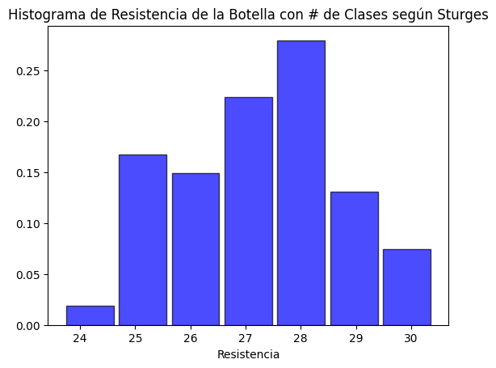

```python
# Generando el histograma
import matplotlib.pyplot as plt
plt.hist(df, bins=k, edgecolor='black', alpha=0.7, color='blue', rwidth=.90, density=True, cumulative=False)
plt.title("Histograma de Resistencia de la Botella con # de Clases según Sturges")
plt.xlabel("Resistencia")
plt.show()
```

##### Regla de Scott

```python
# Calculando el número de clases con la regla de Scott
h = 3.5 * df.std() / n**(1/3)  ##Verificar con profesor si es correcto y si se aplica k = xmax - xmin / h y si lleva el exponente en positivo
k = (df.max() - df.min()) / h
k = math.ceil(k)
print("El número de clases según el método Scott es:", k)
```

```
El número de clases según el método Scott es: 6
```

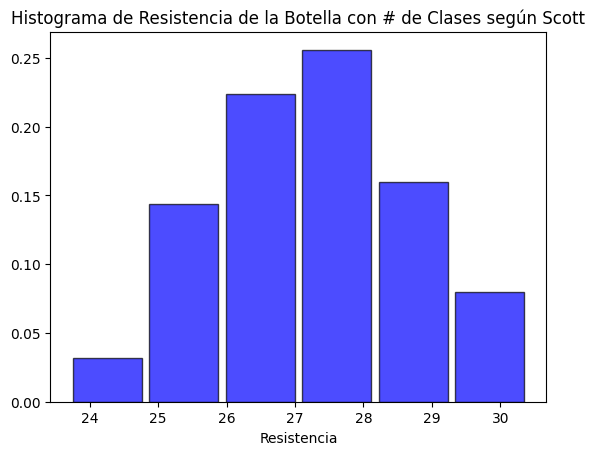

```python
# Generando el histograma
plt.hist(df, bins=k, edgecolor='black', alpha=0.7, color='blue', rwidth=.90, density=True, cumulative=False)
plt.title("Histograma de Resistencia de la Botella con # de Clases según Scott")
plt.xlabel("Resistencia")
plt.show()
```

##### Regla de Diaconis

```python
# Calculando el número de clases con la regla de Freedman-Diaconis
#Rango intercuartil
q1 = df.quantile(0.25)
q3 = df.quantile(0.75)
iqr = q3 - q1

h = 2 * iqr *n**(-1/3) # Aquí sí soporta el exponente en negativo
k = (df.max() - df.min()) / h
k = math.ceil(k)
print("El número de clases según el método Freedman-Diaconis es: ", k)
```

```
El número de clases según el método Freedman-Diaconis es:  7
```

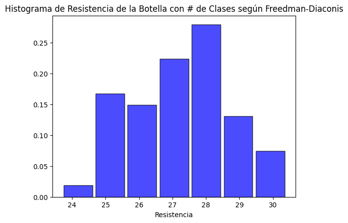

```python
# Generando el histograma
plt.hist(df, bins=k, edgecolor='black', alpha=0.7, color='blue', rwidth=.90, density=True, cumulative=False)
plt.title("Histograma de Resistencia de la Botella con # de Clases según Freedman-Diaconis")
plt.xlabel("Resistencia")
plt.show()
```

#### b. Realice un diagrama de caja y bigotes. Analice el comportamiento de los datos. ¿Existen datos atípicos? ¿Qué se debería hacer al respecto?

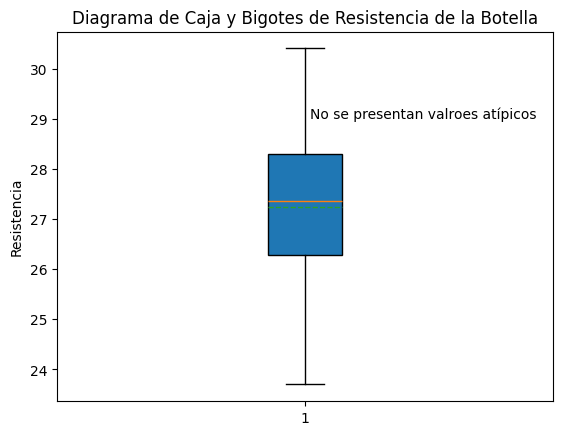

```python
# Generando un diagrama de caja y bigotes
plt.boxplot(df, vert=True, patch_artist=True, showmeans=True, meanline=True, showcaps=True, notch=False, showfliers=True)
plt.title("Diagrama de Caja y Bigotes de Resistencia de la Botella")
plt.ylabel("Resistencia")
# Agregando un comentario dentro del diagrama
plt.text(1.01, 29, "No se presentan valroes atípicos")
plt.show()
```

No se presentaron valores atípicos, dependiendo del tipo de valor atípico se podrían eliminar ya que podrían ser difíciles de tratar o podrían introducir "ruido" a los datos.

Se podrían hacer técnicas de tratamiento de los outliers como sustituir por valores menos extremos, aplicar transformaciones, remplazando valores por algún método de imputación o crear algún modelo para tratar esos datos.

### c) Estime, con una confianza de 94%, ¿cuál sería la resistencia promedio de los envases?

```python
# Calculando el nivel de confianza del 94% para la media de la resistencia de la botella
from scipy.stats import norm
import numpy as np

n = len(df)
media = df.mean()
desviacion_estandar = df.std()

n_confianza = 0.94

#Calculo de z-critical value
z_critical = norm.ppf((1+n_confianza)/2)

#Calculo de margen de error
margen_error = z_critical * (desviacion_estandar / np.sqrt(n))

# Calculo de margen de error
limite_inferior = media - margen_error.iloc[0]
limite_superior = media + margen_error.iloc[0]

dif = limite_superior.iloc[0] - limite_inferior.iloc[0]

print("El margen de error es:", margen_error.iloc[0].round(4))
print("La diferencia entre los límites es:", dif)
print(f"El intervalo de confianza para la media de {n_confianza*100}% la resistencia de la botella es: ({limite_inferior.iloc[0].round(4)} - {limite_superior.iloc[0].round(4)})")
```

```
El margen de error es: 0.3595
La diferencia entre los límites es: 0.7190313973443949
El intervalo de confianza para la media de 94.0% la resistencia de la botella es: (26.8869 - 27.6059)
```

El promedio de las botellas está entre 26.88kg y 27.60kg, con un nivel de confianza del 94%

### D.Antes del estudio se suponía que la resistencia promedio era de 25kg. Dada la evidencia de los datos, ¿tal supuesto es correcto? ¿Qué tipo de prueba estadística se debe realizar? Planteé las hipótesis correspondientes y concluya adecuadamente.

```python
# Prueba de Hipótesis

# Hipótesis nula: La resistencia promedio de la botella es de 25
# Hipótesis alternativa: La resistencia promedio de la botella no es de 25
import scipy.stats as stats
import numpy as np

#Libreria para calclular p-value
from scipy.stats import t


media = df.iloc[1:].mean()
media = media.iloc[0]

mu0 = 25

s = df.std()
s = s.iloc[0]

n = len(df)

alpha = 0.05

# Calculando el valor crítico z
z_critical = (media - mu0) / (s / np.sqrt(n))

# Calculando el valor p
p = 2 * (1 - stats.t.cdf(abs(z_critical), n-1))

print("El valor crítico z es:", z_critical)
print("El valor p es:", p)

if p < alpha:
    print("Rechazamos la hipótesis nula")
else:
    print("No rechazamos la hipótesis nula")
```

```
El valor crítico z es: 11.651898163378
El valor p es: 2.220446049250313e-16
Rechazamos la hipótesis nula
```

En este caso al ser mucho menor el P_value que alpha establecido, podemos decir que rechazamos la hipótesis nula, es decir, los datos no tenían un promedio de 25kg de resistencia.

### e) Con los datos anteriores estime, con una confianza del 98%, ¿cuál es la desviación estándar poblacional (del proceso)?

#### Utilizando chi-cuadrada

```python
# Calculando la desviación estándar de la resistencia de la botella dado un nivel de confianza del 98%
import scipy.stats as stats
import numpy as np

n = len(df) # Tamaño de la muestra
s = df.std() # Desviación estándar de la muestra
s = s.iloc[0] # Valor de la desviación estándar
n_confianza = 0.98 # Nivel de confianza

# Chi-Squared Critical values
chi2_lower = stats.chi2.ppf((1 - n_confianza) / 2, n-1)
chi2_upper = stats.chi2.ppf((1 + n_confianza) / 2, n-1)

lower_var = (n-1) * s**2 / chi2_upper
upper_var = (n-1) * s**2 / chi2_lower

lower_std = np.sqrt(lower_var)
upper_std = np.sqrt(upper_var)

print(f"El intervalo de confianza para la desviación estándar de la resistencia de la botella es: ({lower_std.round(4)} - {upper_std.round(4)}) para un nivel de confianza del {n_confianza*100}%")
```

```
El intervalo de confianza para la desviación estándar de la resistencia de la botella es: (1.1694 - 1.8309) para un nivel de confianza del 98.0%
```

## 3.- En un laboratorio bajo condiciones controladas, se evaluó, para 10 hombres y 10 mujeres, la temperatura que cada persona encontró más confortable. Los resultados en grados Fahrenheit fueron los siguientes:

### a) ¿Las muestras son dependientes o independientes? Explique.

```python
df = pd.read_excel('../data/raw/Actividad Transformaciones e Inferencia Estadística.xlsx', sheet_name='Ejercicio 3')
df
```

|  | Mujer | Hombre |
| --- | --- | --- |
| 0 | 75 | 74 |
| 1 | 77 | 72 |
| 2 | 78 | 77 |
| 3 | 79 | 76 |
| 4 | 77 | 76 |
| 5 | 73 | 73 |
| 6 | 78 | 75 |
| 7 | 79 | 73 |
| 8 | 78 | 74 |
| 9 | 80 | 75 |

Se puede apreciar que las muestras son independientes debido a que no cuentan con una correlación, es decir, los datos de temperatura para mujer no dependen de la temperatura que eligieron los hombres y de igual forma al revés.

### b. ¿La temperatura promedio más confortable es igual para hombre que para mujeres? ¿Qué tipo de prueba estadística se debe realizar? Planteé las hipótesis correspondientes y concluya adecuadamente.

Se debe de realizar una prueba de hipotesos de dos muestras, en este caso. Prueba Z

```python
# Pruebas de hipotesis de dos muestras
mu1 = 70
mu2 = 70
sigma1 = df.iloc[0:11, 0].std() # Desviación estándar para Mujeres
sigma2 = df.iloc[0:11, 1].std() # Desviación estándar para Hombres


n1 = len(df.iloc[0:11, 0]) # Tamaño de la muestra para Mujeres
n2 = len(df.iloc[0:11, 1]) # Tamaño de la muestra para Hombres

mean1 = df.iloc[0:11, 0].mean() # Media para Mujeres
mean2 = df.iloc[0:11, 1].mean() # Media para Hombres

print(f"Media para Mujeres: {round(mean1, 2)}% Desviación estándar para Mujeres: {round(sigma1, 5)}")
print(f"Media para Hombres: {round(mean2, 2)}% Desviación estándar para Hombres: {round(sigma2, 5)}")

z_score = (mean1 - mean2) / np.sqrt(sigma1**2/n1 + sigma2**2/n2)
p_value = 2 * (1 - stats.norm.cdf(abs(z_score)))

print(f"Z-Score: {round(z_score, 5)}")
print(f"P-Value: {round(p_value, 5)}")

alpha = 0.05
if p_value < alpha:
    print("Rechazamos la hipótesis nula")
else:
    print("No rechazamos la hipótesis nula")
```

```
Media para Mujeres: 77.4% Desviación estándar para Mujeres: 2.06559
Media para Hombres: 74.5% Desviación estándar para Hombres: 1.58114
Z-Score: 3.52542
P-Value: 0.00042
Rechazamos la hipótesis nula
```

Podemos decir que las temperaturas promedio entre hombre y mujer son diferentes debido a que se tiene la evidencia para rechazar la hipótesis nula.

### c) ¿Los datos poseen la misma variabilidad? ¿Qué tipo de prueba estadística se debe realizar? Planteé las hipótesis correspondientes y concluya adecuadamente.

La hipótesis Nula es que las varianzas son las mismas

```python
# Prueba de hipótesis de dos muestras con varianzas desconocidas
mu1 = 70
mu2 = 70

var1 = df.iloc[0:11, 0].var() # Varianza para Mujeres
var2 = df.iloc[0:11, 1].var() # Varianza para Hombres

f_statistic = var1 / var2

df1 = len(df.iloc[0:11, 0]) - 1
df2 = len(df.iloc[0:11, 1]) - 1

p_value = 2 * min(stats.f.cdf(f_statistic, df1, df2), 1 - stats.f.cdf(f_statistic, df1, df2))

print(f"F-Statistic: {round(f_statistic, 5)}")
print(f"P-Value: {p_value}")

alpha = 0.05
if p_value < alpha:
    print("Rechazamos la hipótesis nula")
else:
    print("No rechazamos la hipótesis nula")
```

```
F-Statistic: 1.70667
P-Value: 0.4380709879241653
No rechazamos la hipótesis nula
```

Para encontrar una variabilidad se puede utilizar una Prueba F, la cuál nos ayudará a encontrar la diferencia entre las varianzas y también generar una respuesta a la hipótesis nula, la cuál es que la no tienen variabilidad.

En este caso no se rechaza la hipótesis nula debido a que no existen prueba suficientes para decir que rechazamos la hipótesis nula, por lo tanto, se dice que poseen la misma variabilidad.

## 4.- La prueba actual de un solo disco se tarda 2 minutos. Se supone un nuevo método de prueba que consiste en medir solamente los radios 24 y 57, donde casi es seguro que estará el valor mínimo buscado. Si el método nuevo resulta igual de efectivo que el método actual se podrá reducir en 60% el tiempo de prueba. Se plantea un experimento donde se mide la densidad mínima de metal en 18 discos usando tanto el método actual como el método nuevo. Los resultados están ordenados horizontalmente por disco. Así 1.88 y 1.87 es el resultado para el primer disco con ambos métodos.

### a) ¿Las muestras son dependientes o independientes? Explique

```python
df = pd.read_excel('../data/raw/Actividad Transformaciones e Inferencia Estadística.xlsx', sheet_name='Ejercicio 4')
df
```

|  | Método Actual | Método Nuevo |
| --- | --- | --- |
| 0 | 1.88 | 1.87 |
| 1 | 1.84 | 1.90 |
| 2 | 1.83 | 1.85 |
| 3 | 1.90 | 1.88 |
| 4 | 2.19 | 2.18 |
| 5 | 1.89 | 1.87 |
| 6 | 2.27 | 2.23 |
| 7 | 2.03 | 1.97 |
| 8 | 1.96 | 2.00 |
| 9 | 1.98 | 1.98 |
| 10 | 2.00 | 1.99 |
| 11 | 1.92 | 1.89 |
| 12 | 1.83 | 1.78 |
| 13 | 1.94 | 1.92 |
| 14 | 1.94 | 2.02 |
| 15 | 1.95 | 2.00 |
| 16 | 1.93 | 1.95 |
| 17 | 2.01 | 2.05 |

En esta ocasión sí existe una dependencia entre las muestras debido a que los discos son iguales, los métodos dependen del disco en cuestión.

### b) ¿Qué tipo de prueba estadística se debe realizar? Planteé las hipótesis correspondientes y concluya adecuadamente.

Se podría realizar una prueba T-sutent para poder evaluar las medias y determinar si vale la pena cambiar al nuevo método.

```python
# Generando una prueba de hipótesis T-student para una muestra

n1 = len(df.iloc[0:11, 0]) # Tamaño de la muestra método actual
n2 = len(df.iloc[0:11, 1]) # Tamaño de la muestra método nuevo

mean1 = df.iloc[0:11, 0].mean() # Media método actual
mean2 = df.iloc[0:11, 1].mean() # Media método nuevo

std1 = df.iloc[0:11, 0].std() # Desviación estándar método actual
std2 = df.iloc[0:11, 1].std() # Desviación estándar método nuevo

t_score, p_value = stats.ttest_ind(df.iloc[0:11, 0], df.iloc[0:11, 1], equal_var=False)

print(f"T-Score: {round(t_score, 5)}")
print(f"P-Value: {round(p_value, 6)}")

alpha = 0.05
if p_value < alpha:
    print("Rechazamos la hipótesis nula")
else:
    print("No rechazamos la hipótesis nula")
```

```
T-Score: 0.07964
P-Value: 0.937327
No rechazamos la hipótesis nula
```

### c) ¿Recomienda la adopción del nuevo método? Argumente su respuesta.

La adopción del nuevo método puede ser recomendada si hay algún beneficio cualitativo, si no lo hay, no sería recomendable ya que podría involucrar costos para capacitar a el personal y realmente no habría una mejora en la eficiencia del proceso.